# Activity 2: Intro to Statistics and Weather

Heather Kropp

#### *ENVST 206: Environmental Data Science, Hamilton College*

## Instructions

There are 10 questions to this activity. Save your answers in word document that you will hand in on Blackboard using a .pdf or .docx extension. Keep your script file in your GitHub folder and make sure that all changes are pushed to GitHub. Code for all questions should be clearly commented with the question number. You will include a link to your script file as a part of your final question in this activity. The assignment is worth 30 points.

I will provide a lot of code examples as a part of this Activity. As the course progresses, I will gradually provide less code. You will have to adapt this code in the questions. To do this successfully, you will likely need to refer to R documentation and online resources to thoroughly understand all parts of the code. Troubleshooting and learning to interpret code is a huge part of learning R! It often involves making a lot of mistakes and getting error messages. That’s great and normal! I’ve been working in R for 12 years, and I still generate a lot of mistakes and error messages! You’ll just get better at fixing them.

## Learning objectives

#### 1. Handling data in R

#### 2. Intro to probability and summary statistics

#### 3. Characterize climate using a probability distribution

## Working with data in R

### *Vectors*

Common types of objects in R include vectors, matrices, and dataframes. Last class, we briefly learned about creating vectors in R. You assign a name to an object using the arrow: **<-** and can make a vector using **c()**. If you remember, R is vectorized so we can automatically apply vector or matrix math to an object. Running the name of an object will print out the object.

```r
#make a vector of tree heights in meters
heights <- c(30,41,20,22)
#convert to cm
heights_cm <- heights*100
heights_cm
```

```
## [1] 3000 4100 2000 2200
```

R uses a very specific notation around vectors. It is helpful for subsetting. Anytime you see square brackets **[ ]** recognize that this is subsetting an object in R. Also note that R always counts starting at one (no zeros like other programming languages!). Whenever you see a colon **:**, know that you are indexing through multiple values.

```r
#look at the first tree height
heights[1]
```

```
## [1] 30
```

```r
#look at the 2nd and 3rd tree heights
heights[2:3]
```

```
## [1] 41 20
```

### *Matrices*

I like to think of matrices as essentially multiple columns of vectors in R. You can set up a matrix using the *matrix()* function. **Functions** are built in to R and will always have parenthesis **()** following the function name. Anything inside of the parentheses is called an **argument**. Here to build a matrix, you need a vector of numbers that fills in the matrix and specify the number of columns or rows. You can also specify how to fill in the matrix (do you go through all columns in each row?). If you ever aren’t sure of arguments for a function, you can use *help* or *?*.

```r
#get more info on the matrix function
help(matrix)
```

Now, make some example matrices. Note the differences in filling in by column vs row.

```r
#set up a matrix with 2 columns and fill in by rows
#first argument is the vector of numbers to fill in the matrix
Mat<-matrix(c(1,2,3,4,5,6), ncol=2, byrow=TRUE)
Mat
```

```
##      [,1] [,2]
## [1,]    1    2
## [2,]    3    4
## [3,]    5    6
```

```r
#set up a matrix that fills in by columns
#first argument is the vector of numbers to fill in the matrix
Mat.bycol<-matrix(c(1,2,3,4,5,6), ncol=2, byrow=FALSE)
Mat.bycol
```

```
##      [,1] [,2]
## [1,]    1    4
## [2,]    2    5
## [3,]    3    6
```

Notice when the both the matrices are run, the output now has square bracket labels with two spots. This notation will always be formatted **[row,column]**. You can use this notation to refer to specific spots in a matrix using the name of the matrix.

```r
#subset the matrix to look at row 1, column2
Mat.bycol[1,2]
```

```
## [1] 4
```

An opening in a square bracket after or before a comma means refer to all items in that slot. You’ll notice the output is a vector when subsetting.

```r
#look at all values in row 1
Mat.bycol[1,]
```

```
## [1] 1 4
```

```r
#look at all values in column 2
Mat.bycol[,2]
```

```
## [1] 4 5 6
```

### *Dataframes*

Today, we will look at weather patterns and extreme events from five sites across the US. I downloaded this data from NOAA, and I’ve included instructions for downloading this type of data for future reference.

Most data that you will work with is too large to be typed into R scripts. A lot of the data will be available in spreadsheet or text file format. You will want to work with this type of data as a dataframe. Dataframes are are matrices where columns have names and rows contain observations for the same entity. This works a lot like a spreadsheet, but we can apply our vector and matrix utilities in R. For example, we will read in a data file for weather data where columns contain data for temperature and precipitation, and each row has an observation for the same day and weather station. You may be used to working with data in excel spreadsheets with a .xlsx extension that is proprietary to Microsoft. This is not ideal to work with, and we will work with **.csv (comma separated values file)**. This file contains the text version of an excel spreadsheet where the values for each cell are included in the file and the designation of a new cell starts with a comma. You can always resave an .xlsx file as a .csv. You can save any excel file as a .csv file when you click save as. Let’s read in a file I’ve already formatted for you.

First, go to the *Data* folder (this folder is read only access). Copy the folder *a02* to your student folder. Make a note of the file path you will need for this folder. You will find documentation on the data, information about the data request that I made, and general instructions for accessing this weather data. You will need to download this data. You will want to save this outside of your repository. Often R does better reading in file paths with two *\* in a Windows environment so you will use that designation in your file path if you are working from a windows computer. You will also need quotes around your file path. Here is an example of my file path on a mac (I make a lot of folders!).

```r
#read in weather station file from the data folder
#you will need to adjust the directory to match your folder
#mac example
datW <- read.csv("/Users/hkropp/Google Drive/teaching/2020/Fall 2020/EnvDataSci/activity/data/activity 2/noaa_weather/noaa2011124.csv")
#windows example
#datW <- read.csv("c:\\Users\\hkropp\\Google Drive\\teaching\\2020\\Fall 2020\\EnvDataSci\\activity\\data\\activity 2\\noaa_weather\\noaa2011124.csv")
```

You’ll also find in the folder the full documentation of the data (metadata) and information about the download (for example indicates that I specified metric units). Let’s take a look at the data. You can view the dataframe in Rstudio in the *Environment* tab by clicking on the dataframe name *datW*. You can also find out more information about the dataframe as shown below:

```r
#get more information about the dataframe
str(datW)
```

```
## 'data.frame':    157849 obs. of  11 variables:
##  $ STATION  : chr  "USC00305512" "USC00305512" "USC00305512" "USC00305512" ...
##  $ NAME     : chr  "MORRISVILLE 6 SW, NY US" "MORRISVILLE 6 SW, NY US" "MORRISVILLE 6 SW, NY US" "MORRISVILLE 6 SW, NY US" ...
##  $ LATITUDE : num  42.8 42.8 42.8 42.8 42.8 ...
##  $ LONGITUDE: num  -75.7 -75.7 -75.7 -75.7 -75.7 ...
##  $ ELEVATION: num  512 512 512 512 512 ...
##  $ DATE     : chr  "1930-01-01" "1930-01-02" "1930-01-03" "1930-01-04" ...
##  $ PRCP     : num  1.3 0 0 5.1 0 5.3 0 7.4 0 0 ...
##  $ TMAX     : num  2.8 7.2 3.9 -1.1 -1.7 10 11.7 11.1 11.7 -2.2 ...
##  $ TMIN     : num  -7.8 1.7 -2.2 -12.8 -21.7 -8.3 -3.3 7.8 -5 -12.8 ...
##  $ dateF    : chr  "1930-01-01" "1930-01-02" "1930-01-03" "1930-01-04" ...
##  $ year     : int  1930 1930 1930 1930 1930 1930 1930 1930 1930 1930 ...
```

In the output, you’ll see the number of rows and columns of the data frame in the first line and a preview of the first few rows of data in each preview. You’ll notice there are two types of data: **numeric** and **character**. In new versions of R >4.0.0, all data containing any non-numeric data will be treated as characters. It would be helpful for us to treat these characters as a **Factor**. Factor data types in R are automatically assigned to repeating character strings. R treats them both as a character string and a discrete number assigned to each unique character string. In the *NAME* column, you’ll notice there site names. It would be helpful to refer to these sites as sites 1, 2, 3 and so forth rather than the long station names. Let’s convert this data type into a factor. We can simply reassign it.

```r
datW$NAME <- as.factor(datW$NAME)
```

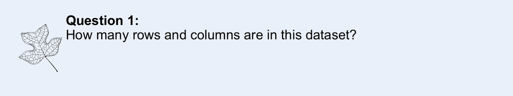

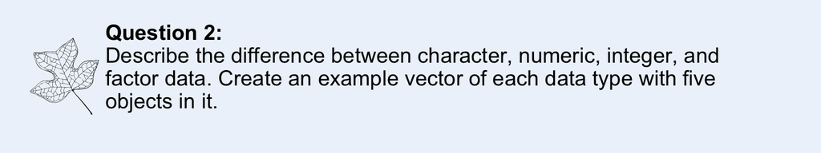

### *Descriptive Statistics and Histograms*

Let’s run some descriptive statistics on the weather data. If you look at the snapshot of the metadata (full file on the server) below, you will find information about the observations in each column. Note that I downloaded with the metric option.

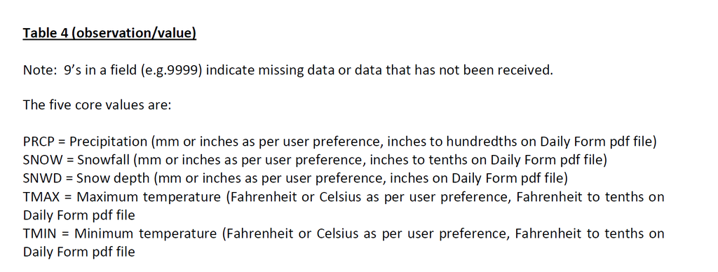

Let’s start by looking at the data using some basic summary statistics. The **mean** is a measure of central tendency of our data. You have probably calculated it at some point by adding all of you observations and dividing by the total number of observations. This is the same as calculating the **average** of our data. In some fields, there is careful phrasing around the mean versus average, and mean may be used more specifically for a probability distribution or when the data more broadly represents a population. We will use the term mean here for simplicity and consistency. Since we have a large amount of observations, we can assume the average of our data adequately represents the mean of the distribution of data. There is a built in function in R called **mean**. We will also want to calculate the **standard deviation**. This measures the spread of the observations around the mean, and keeps the units the same as the mean.

Also note that we have data from five sites with very different climates. We will want to describe annual patterns for each site separately.

We could start by looking at the mean of a single site using the **mean** function. We can check all site names using the **levels** function. You can subset to a single site by using square brackets and indicating that we want a vector for all *TMAX* values where the *NAME* is equal to *ABERDEEN, WA US*.

```r
#find out all unique site names
levels(datW$NAME)
```

```
## [1] "ABERDEEN, WA US"                  "LIVERMORE, CA US"
## [3] "MANDAN EXPERIMENT STATION, ND US" "MORMON FLAT, AZ US"
## [5] "MORRISVILLE 6 SW, NY US"
```

```r
#look at the mean maximum temperature for Aberdeen
mean(datW$TMAX[datW$NAME == "ABERDEEN, WA US"])
```

```
## [1] NA
```

You get a NA value here. That’s because there is missing data in this data set. NA is a specification that allows you to know that the data is missing and we should not expect a value. NA is handled differently in R and is neither a number or character. Luckily there is an argument in mean that allows us to ignore NAs in the calculation.

```r
#look at the mean maximum temperature for Aberdeen
#with na.rm argument set to true to ingnore NA
mean(datW$TMAX[datW$NAME == "ABERDEEN, WA US"], na.rm=TRUE)
```

```
## [1] 14.68515
```

We’ll also take a look at the **standard deviation** of the maximum temperature. R abbreviates this function name as **sd**.

```r
#next look at the standard deviation
sd(datW$TMAX[datW$NAME == "ABERDEEN, WA US"], na.rm=TRUE)
```

```
## [1] 5.834647
```

Now you will see the daily maximum temperature in Aberdeen is 14.68 °C. Since this is the mean across many decades of observations, this value can help tell us about the climate of the site. Before we move on, average daily temperature is often more helpful to evaluate temperature than maximum and minimum. This is the typical temperature that occurred in a single day. The average is always halfway between the minimum and maximum. We can calculate it as follows:

```r
#calculate the average daily temperature
#This temperature will be halfway between the minimum and maximum temperature
datW$TAVE <- datW$TMIN + ((datW$TMAX-datW$TMIN)/2)
```

Notice how I was able to type in a single calculation and it was applied to all rows of TMIN and TMAX in datW. For this calculation, I created a new column in datW called TAVE. Remember the convention for referring to a column in a dataframe is always *dataframe$column*.

The above method of calculating means is not very efficient. We want to look at the mean of the daily average temperature for all locations. This would mean typing new lines of code 5 seperate times. However, you can use the **aggregate** function to calculate means across an indexing value.

```r
#get the mean across all sites
#the by function is a list of one or more variables to index over.
#FUN indicates the function we want to use
#if you want to specify any function specific arguments use a comma and add them after the function
#here we want to use the na.rm arguments specific to
averageTemp <- aggregate(datW$TAVE, by=list(datW$NAME), FUN="mean",na.rm=TRUE)
averageTemp
```

```
##                            Group.1         x
## 1                  ABERDEEN, WA US 10.432268
## 2                 LIVERMORE, CA US 15.381992
## 3 MANDAN EXPERIMENT STATION, ND US  5.568997
## 4               MORMON FLAT, AZ US 22.019010
## 5          MORRISVILLE 6 SW, NY US  6.655229
```

```r
#change the automatic output of column names to be more meaningful
#note that MAAT is a common abbreviation for Mean Annual Air Temperature
colnames(averageTemp) <- c("NAME","MAAT")
averageTemp
```

```
##                               NAME      MAAT
## 1                  ABERDEEN, WA US 10.432268
## 2                 LIVERMORE, CA US 15.381992
## 3 MANDAN EXPERIMENT STATION, ND US  5.568997
## 4               MORMON FLAT, AZ US 22.019010
## 5          MORRISVILLE 6 SW, NY US  6.655229
```

The names in this dataset are long. Let’s convert the factor data to the underlying numbers to reference them more quickly. This will help you get a sense of the numbers that are assigned to factor data behind the scenes. You will have to reference the number again for the name.

```r
#convert level to number for factor data type
#you will have to reference the level output or look at the row of data to see the character designation.
datW$siteN <- as.numeric(datW$NAME)
```

Let’s take a look at how often different temperature values are observed at each site. You’ll use a graphical tool called a histogram. A histogram shows the frequency of temperature observations in different bins.

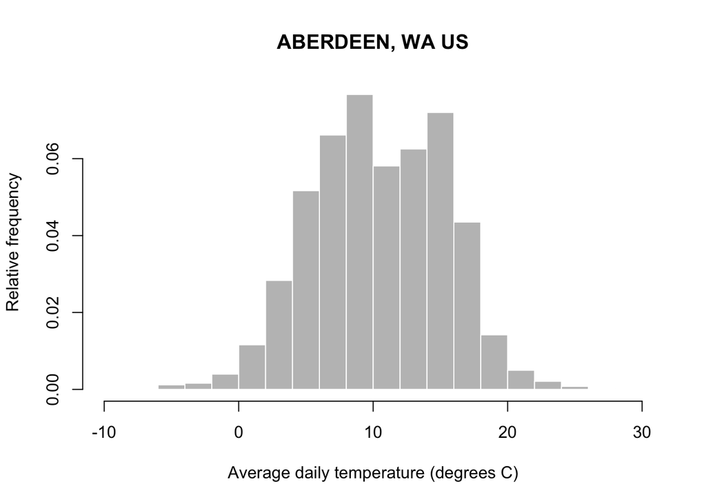

```r
#make a histogram for the first site in our levels
#main= is the title name argument.
#Here you want to paste the actual name of the factor not the numeric index
#since that will be more meaningful.
hist(datW$TAVE[datW$siteN == 1],
        freq=FALSE,
        main = paste(levels(datW$NAME)[1]),
        xlab = "Average daily temperature (degrees C)",
        ylab="Relative frequency",
        col="grey75",
        border="white")
```

Paste is a very helpful function that will put the name of our station into the title. This means you don’t have to type it all out! You could copy and paste this function, changing the site number from 1 to 2, 3, 4, or 5 and make entirely new histograms that are properly labeled. This means that you don’t have to do the work of typing all of the names out.

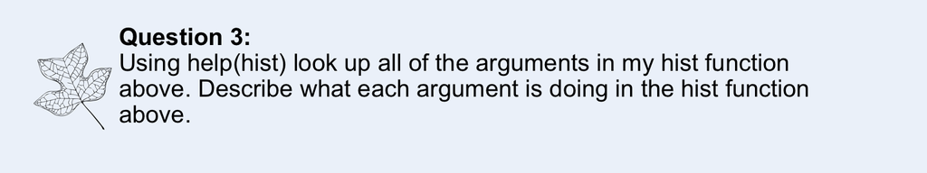

To get a better idea of how the summary statistics describe the data, let’s take a closer look at the plot. I’ll add a red solid line for the mean and red dashed lines for the standard deviation from the mean. I’ll add a dotted line to mark the values that are within two standard deviations of the mean.

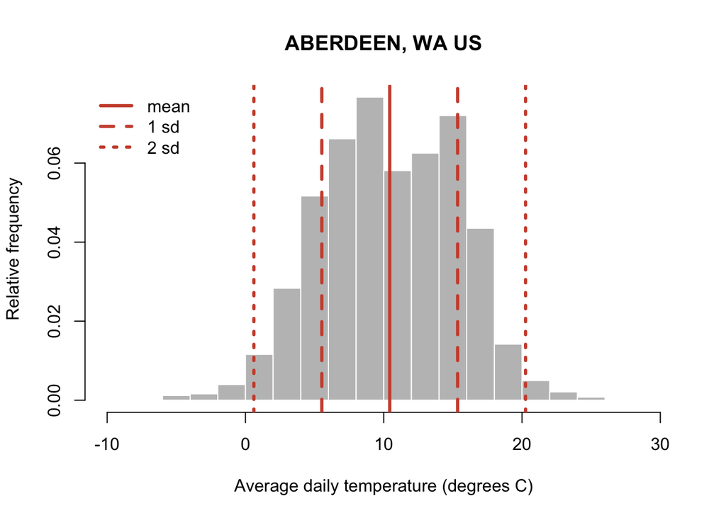

You’ll notice that a lot of the data in the standard deviation encompasses a lot of the data. If we look 2 standard deviations within the mean, almost all of the data is included.

### *Probability distributions*

The data distribution that we just viewed has a very particular shape. The temperature observations are most frequent around the mean and we rarely observe data 2 standard deviations from the mean. The distribution is also symmetrical. We can describe this occurance of different values of data more formally with a **probability distribution**. Probability distributions have a lot of mathematical properties that are useful. We use **parameters** to help describe the shape of how data is distributed. This temperature data follows a **normal distribution**. This type of distribution is very common and relies on **two parameters: the mean and standard deviation** to describe the data distribution. Below is an image of the normal distribution where zero represents the value at the mean of the data and tick marks are designated with standard deviations. This is called a **standard normal** or a **z distribution**.

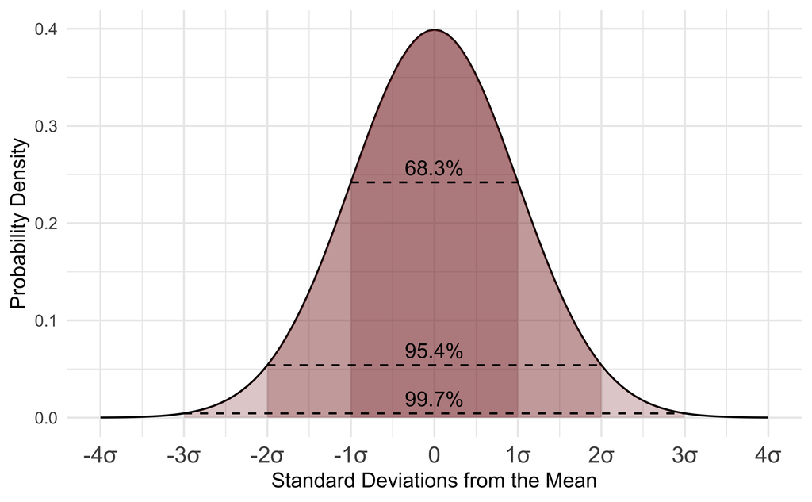

Probability distributions all have functions in R. Below, I used the **dnorm** function to calculate the probability density for a range of temperature values to add to the plot. Remember this probability density alone just gives us the overall shape and relative occurrence, but the density at any given value does not mean a lot by itself.

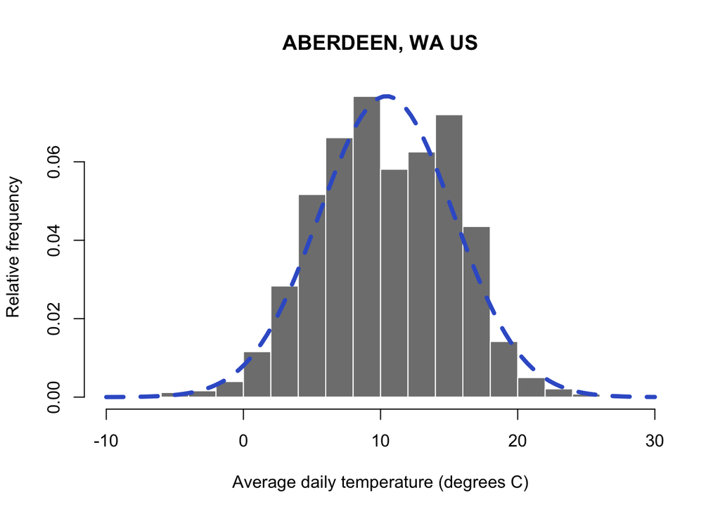

You can now see the blue dashed line over-layed on the histogram. This is the normal distribution using the mean and standard deviation calculated from the data. You’ll notice the normal distribution does a good job of modelling our data. Sometimes it underestimates a data range and at other points it overestimates it, but overall it mirrors the distribution of our data. This means we can rely on properties of the normal to help describe our data statistically! We’ll learn a little more in the coming weeks about how to assess this more formally.

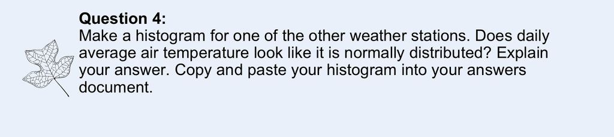

Now let’s revisit how we can use probability think about the occurrence of different air temperature ranges. For a given value of the data, the normal distribution has a probability density associated with observing the value. The probability density doesn’t mean anything at a given value of the data. We can’t really do anything with that particular number. However, when the normal distribution is integrated across a range of values, it yields a probability for the occurrence of the range of values. For those of you that haven’t had calculus, integrating is essentially taking the area under the curve between a range of numbers. In my graph below, you can see the red shading indicates the area below the value of zero on the curve. We have to keep in mind that the range of the normal distribution extends from -$\infty$ to $\infty$. Let’s start by taking a look at all values below freezing in the normal distribution for our Aberdeen weather data. Technically this is the probability of all temperatures below freezing from zero to -$\infty$. Functionally we know some low temperatures would be impossible to observe on earth and the probability of observing values closer to -$\infty$ will be minuscule. You’ll notice that I cut off the axis at -10 and 30 degrees C where the occurance of values outside of this range is so low, it looks like zero.

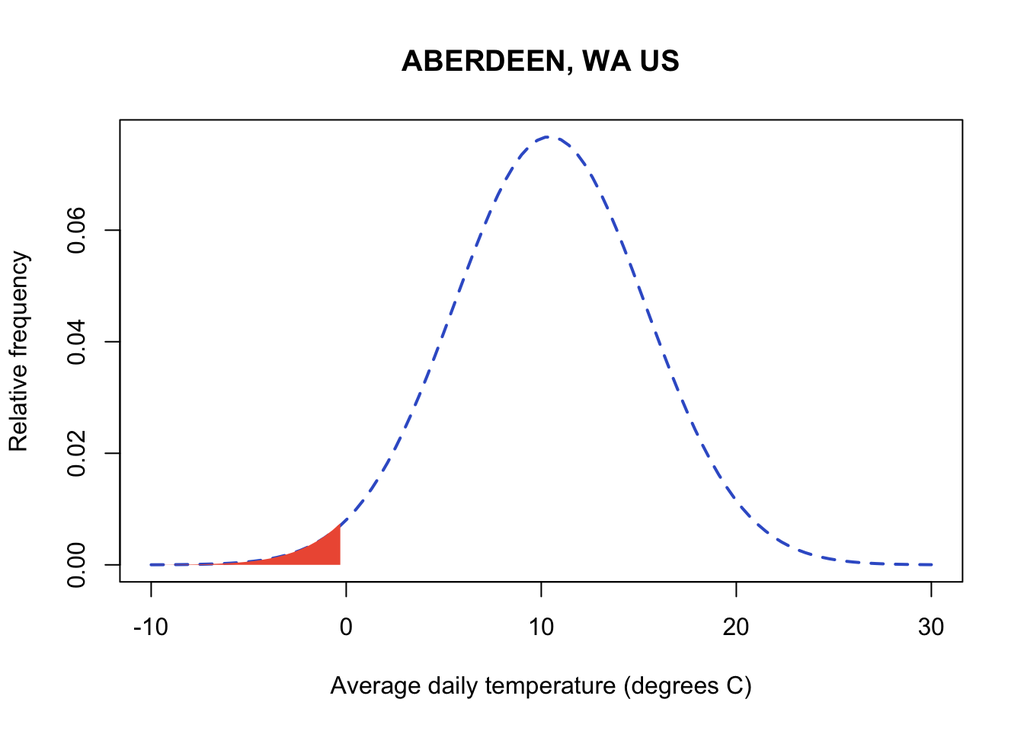

Luckily we don’t have to do any of the work calculating the probability. R has a built in suite of functions for working with probability distributions. You can run the help command documentation for all functions related to the normal distribution. Run the documentation on dnorm to see them all:

```r
help(dnorm)
```

R uses p to designate probability. If we use **pnorm**, we can enter a number as the first argument (the next two arguments are always the mean and standard deviation for the normal), the output will be the **probability of observing that value AND all values below it to -$\infty$.** Let’s calculate the probability of below freezing temperatures. Don’t forget that probabilities always range from 0 to 1. We would have to go integrate across the normal between values of -$\infty$ to $\infty$ to get a probability of 1 in the normal. Below we’ll just focus on all values below freezing:

```r
#pnorm(value to evaluate at (note this will evaluate for all values and below),mean, standard deviation)
pnorm(0,
      mean(datW$TAVE[datW$siteN == 1],na.rm=TRUE),
      sd(datW$TAVE[datW$siteN == 1],na.rm=TRUE))
```

```
## [1] 0.01682526
```

You can see below freezing temperatures are rare at this site and we only expect them to occur about 1.6% of the time. Sometimes it’s easier to think about probability as % occurrence.

I can take advantage of the properties of the distribution and add and subtract areas under the curve to better tailor my ranges of numbers. For example, I might be interested in identifying how often a temperatures between 0-5 degrees occur. First you can find out the probability of all values at 5 degrees or below:

```
## [1] 0.1343358
```

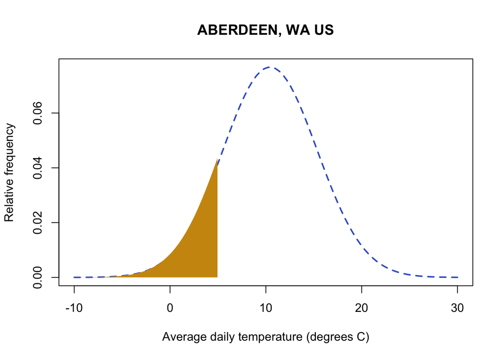

```r
#pnrom with 5 gives me all probability (area of the curve) below 5
pnorm(5,
      mean(datW$TAVE[datW$siteN == 1],na.rm=TRUE),
      sd(datW$TAVE[datW$siteN == 1],na.rm=TRUE))
```

Next, you can subtract the probability for observing values below 0 from your first probability, and you will get the probability of temperatures in the range of 0-5.

```
## [1] 0.1175105
```

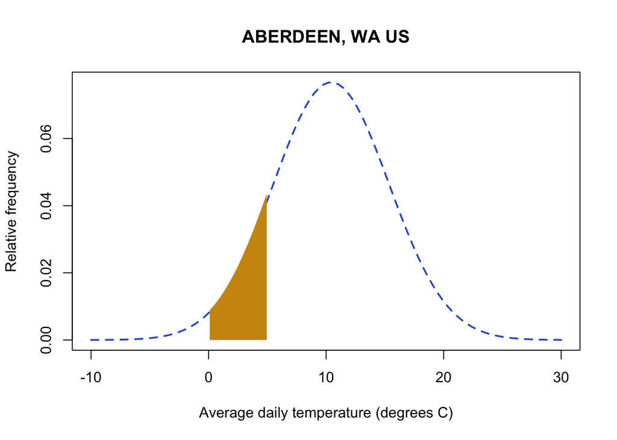

```r
#pnrom with 5 gives me all probability (area of the curve) below 5
pnorm(5,
      mean(datW$TAVE[datW$siteN == 1],na.rm=TRUE),
      sd(datW$TAVE[datW$siteN == 1],na.rm=TRUE)) - pnorm(0,
      mean(datW$TAVE[datW$siteN == 1],na.rm=TRUE),
      sd(datW$TAVE[datW$siteN == 1],na.rm=TRUE))
```

Now let’s evaluate the probability of high temperatures. Knowing that the entire distribution adds up to 1, we can also find the area above a value. For example, let’s look at the probability of temperatures above 20 degrees C.

```
## [1] 0.02569572
```

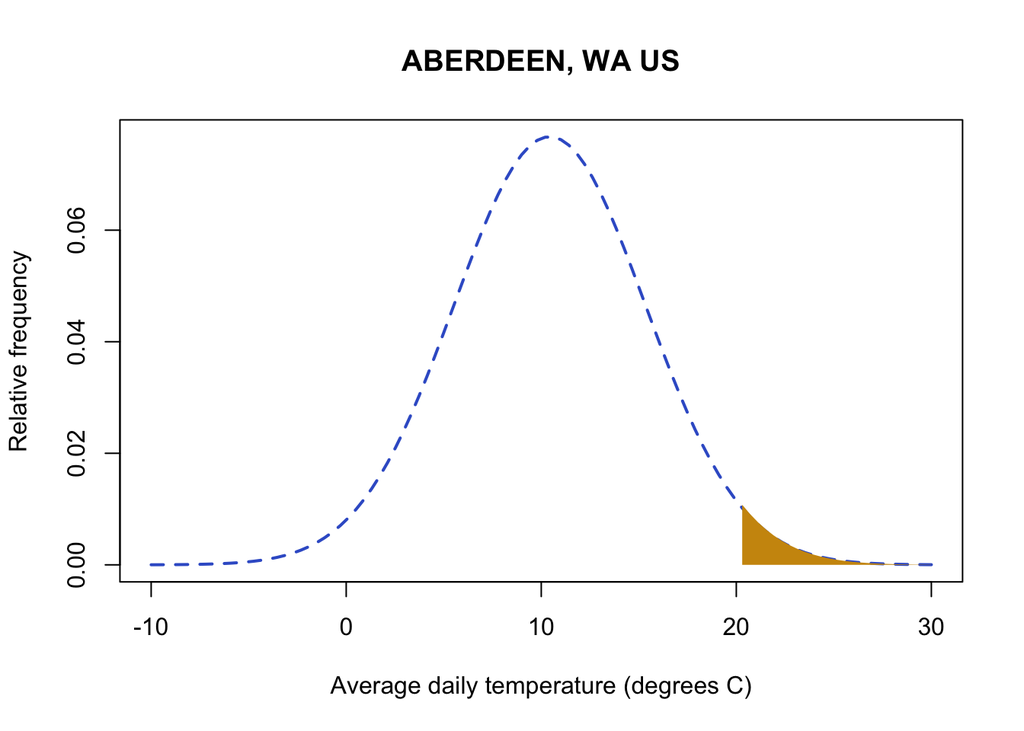

```r
#pnrom of 20 gives me all probability (area of the curve) below 20
#subtracting from one leaves me with the area above 20
1 - pnorm(20,
      mean(datW$TAVE[datW$siteN == 1],na.rm=TRUE),
      sd(datW$TAVE[datW$siteN == 1],na.rm=TRUE))
```

There **qnorm** function will return the value associated with a probability. This is the value in which all values at or below the value equal that probability. Let’s use this to evaluate extreme weather events. Let’s assume everything that occurs with a probability of less than 10% of the time (either hot or cold so anything above 95% or anything below 5%) is unusual. Let’s examine what unusually high temperatures in Aberdeen start at:

```r
#qnorm gives me the value at which all values and below equal the probability in my argument
#Here I'm calculating the value of the 95th quantile or a probability of 0.95
qnorm(0.95,
      mean(datW$TAVE[datW$siteN == 1],na.rm=TRUE),
      sd(datW$TAVE[datW$siteN == 1],na.rm=TRUE))
```

```
## [1] 18.51026
```

This means I expect 95% of the temperature observations to be below this value. Any temperature observations above this value will occur with a probability of 5%.

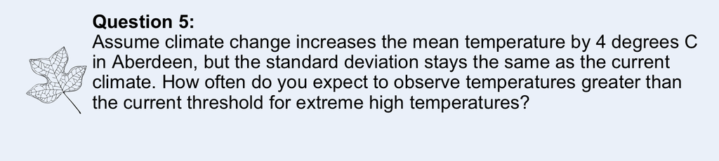

**Note:** Throughout all of my code examples, you’ll notice that I continued to copy and paste the same code for calculating the mean for site 1: `mean(datW$TAVE[datW$siteN == 1],na.rm=TRUE)`. While I did this to help you remember what was going into the function, it gets confusing and messy in long functions. This is a perfect example of why we name variables (with short clear names!) to refer to later on. As this course progresses, we’ll continue to work on creating clean code once you get more comfortable with R.

### *Evaluate patterns in precipitation data*

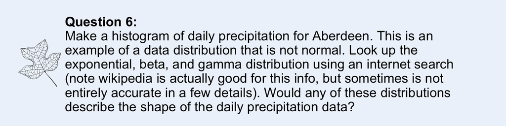

Daily patterns in precipitation are often less useful than looking at total precipitation throughout the entire year. Use your coding knowledge from above to complete the following questions.

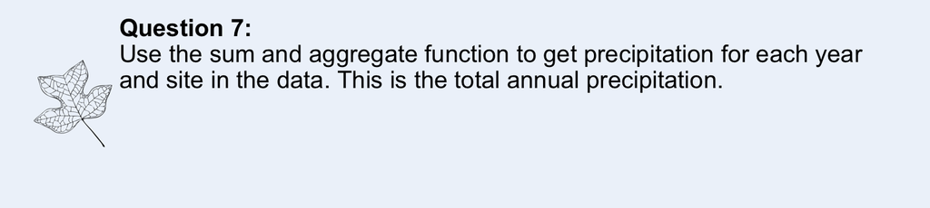

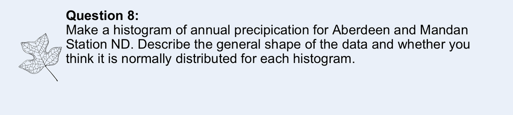

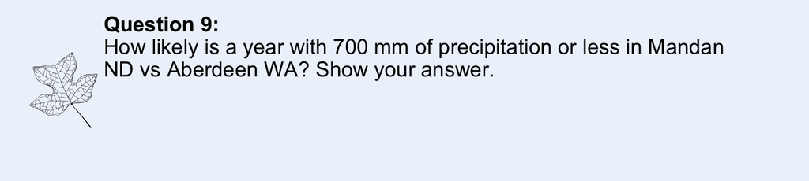

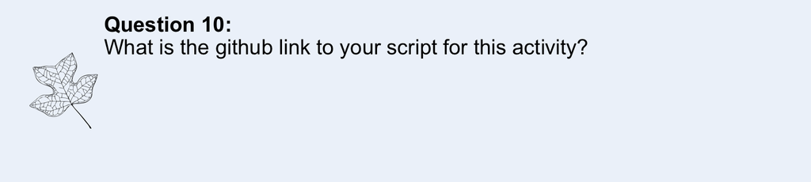